# Bank Marketing - EDA

#### 2.3.3. `previous`

```r
summary(D$previous)
```

```
   Min. 1st Qu.  Median    Mean 3rd Qu.    Max.
  0.000   0.000   0.000   0.173   0.000   7.000
```

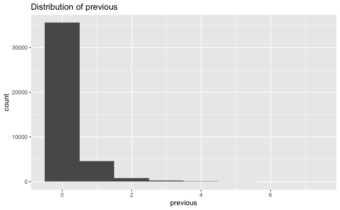

```r
ggplot(D, aes(previous)) + geom_histogram(binwidth = 1) + ggtitle("Distribution of previous")
```

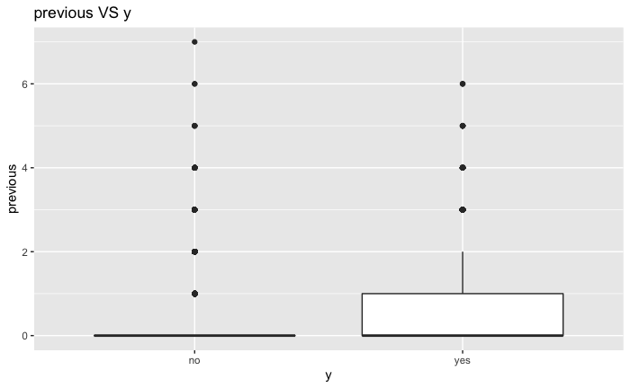

```r
ggplot(D, aes(x=y, y=previous)) + geom_boxplot() + ggtitle("previous VS y")
```

#### 2.3.4. `poutcome`

The feature `poutcome` is outcome of the previous marketing campaign (categorical). For subscribed ratio, the top category is success, while the last category is nonexistent. Since there are variations between subscribed ratio within each category, it has a relationship with `y`.

```r
table(D$poutcome)
```

```
    failure nonexistent     success
       4252       35563        1373
```

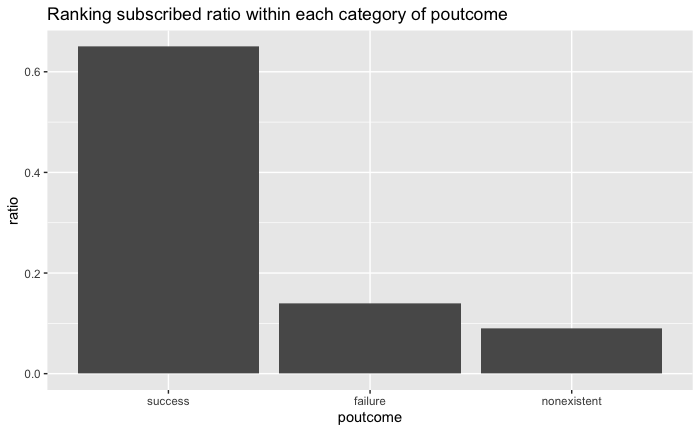

```r
poutcomeRatio = findRatio("poutcome")
ggplot(poutcomeRatio, aes(x=reorder(poutcome, -ratio), y=ratio)) + geom_bar(stat="identity") +
  #theme(axis.text.x = element_text(angle=45, hjust=1)) +
  xlab("poutcome") + ggtitle("Ranking subscribed ratio within each category of poutcome")
```

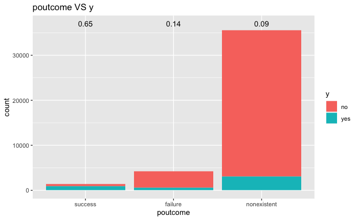

```r
ggplot(merge(D,poutcomeRatio), aes(x=reorder(poutcome,-ratio), fill=y)) + geom_bar() +
  #theme(axis.text.x = element_text(angle=45, hjust=1)) +
  annotate("text", x = 1:3, y=37000, label = sort(poutcomeRatio$ratio, decreasing = T)) +
  xlab("poutcome") + ggtitle("poutcome VS y")

ggsave(filename = "~/Downloads/bank-additional/fig5.png")
```

### 2.4. Social and Economic Indicators

#### 2.4.1. `emp.var.rate`

The feature `emp.var.rate` is employment variation rate - quarterly indicator (numeric). It has strong relationship with `y`.

```r
summary(D$emp.var.rate)
```

```
    Min.  1st Qu.   Median     Mean  3rd Qu.     Max.
-3.40000 -1.80000  1.10000  0.08189  1.40000  1.40000
```

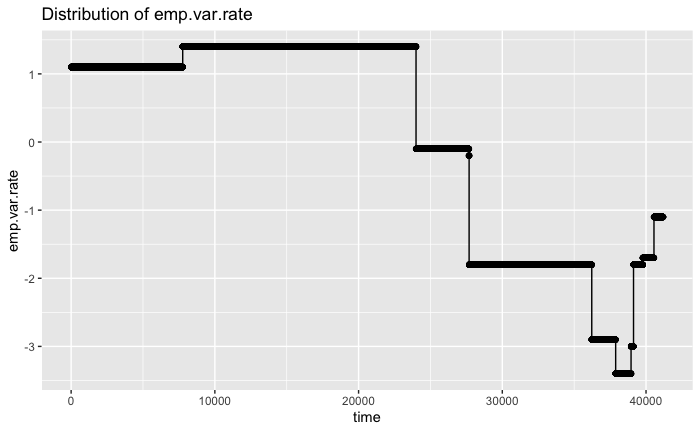

```r
ggplot(D, aes(x=1:nrow(D), y=emp.var.rate)) + geom_point() + geom_line() +
  xlab("time") + ggtitle("Distribution of emp.var.rate")
```

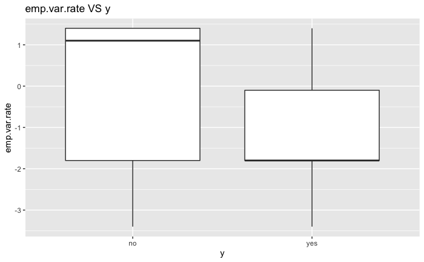

```r
ggplot(D, aes(x=y, y=emp.var.rate)) + geom_boxplot() + ggtitle("emp.var.rate VS y")
```

#### 2.4.2. `cons.price.idx`

The feature `cons.price.idx` is consumer price index - monthly indicator (numeric). It has strong relationship with `y`.

```r
summary(D$cons.price.idx)
```

```
   Min. 1st Qu.  Median    Mean 3rd Qu.    Max.
  92.20   93.08   93.75   93.58   93.99   94.77
```

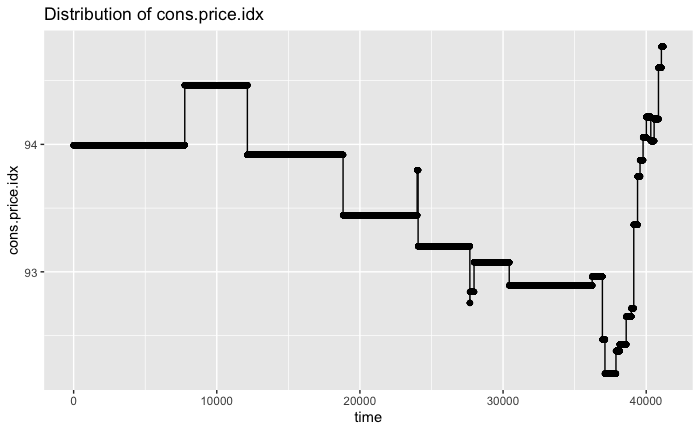

```r
ggplot(D, aes(x=1:nrow(D), y=cons.price.idx)) + geom_point() + geom_line() +
  xlab("time") + ggtitle("Distribution of cons.price.idx")
```

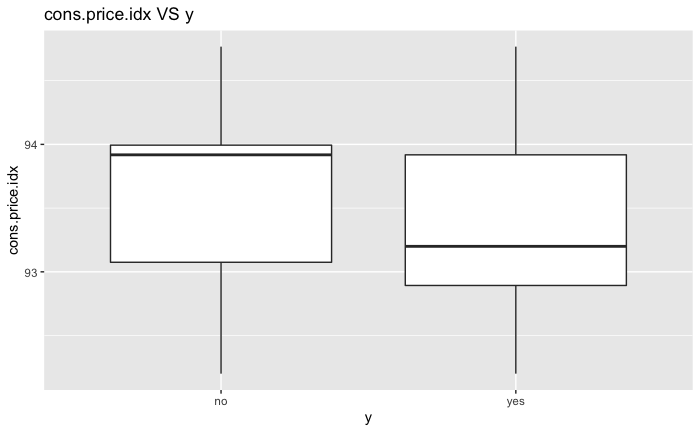

```r
ggplot(D, aes(x=y, y=cons.price.idx)) + geom_boxplot() + ggtitle("cons.price.idx VS y")
```

#### 2.4.3. `cons.conf.idx`

The feature `cons.conf.idx` is consumer confidence index - monthly indicator (numeric). It has a relationship with `y`.

```r
summary(D$cons.conf.idx)
```

```
   Min. 1st Qu.  Median    Mean 3rd Qu.    Max.
  -50.8   -42.7   -41.8   -40.5   -36.4   -26.9
```

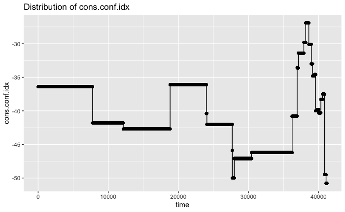

```r
ggplot(D, aes(x=1:nrow(D), y=cons.conf.idx)) + geom_point() + geom_line() +
  xlab("time") + ggtitle("Distribution of cons.conf.idx")
```

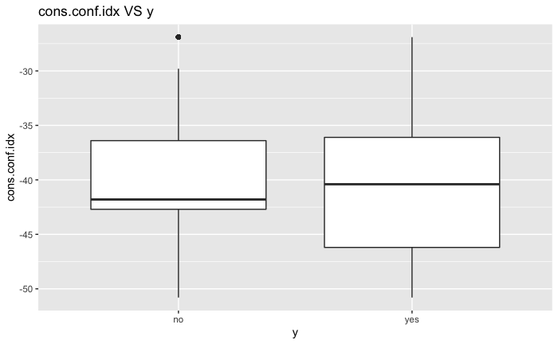

```r
ggplot(D, aes(x=y, y=cons.conf.idx)) + geom_boxplot() + ggtitle("cons.conf.idx VS y")
```

#### 2.4.4. `euribor3m`

The feature `euribor3m` is euribor 3 month rate - daily indicator (numeric). It has a strong relationship with `y`.

```r
summary(D$euribor3m)
```

```
   Min. 1st Qu.  Median    Mean 3rd Qu.    Max.
  0.634   1.344   4.857   3.621   4.961   5.045
```

```r
summary(D$euribor3m[D$y=="yes"])
```

```
   Min. 1st Qu.  Median    Mean 3rd Qu.    Max.
  0.634   0.849   1.266   2.123   4.406   5.045
```

```r
summary(D$euribor3m[D$y=="no"])
```

```
   Min. 1st Qu.  Median    Mean 3rd Qu.    Max.
  0.634   1.405   4.857   3.811   4.962   5.045
```

```r
m0 = median(D$euribor3m[D$y=="no"])
m1 = median(D$euribor3m[D$y=="yes"])

euribor3mRatio = c(sum(D$y=="yes" & D$euribor3m>=m0)/sum(D$euribor3m>=m0), sum(D$y=="yes" & D$euribor3m<=m1)/sum(D$euribor3m<=m1))
euribor3mRatio
```

```
[1] 0.04936139 0.35210009
```

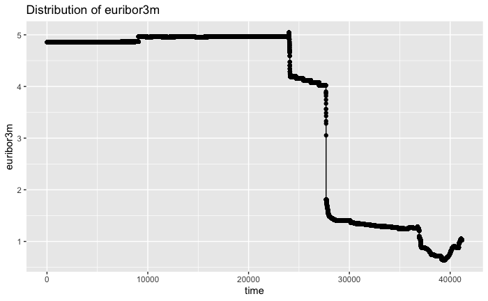

```r
ggplot(D, aes(x=1:nrow(D), y=euribor3m)) + geom_point() + geom_line() +
  xlab("time") + ggtitle("Distribution of euribor3m")
```

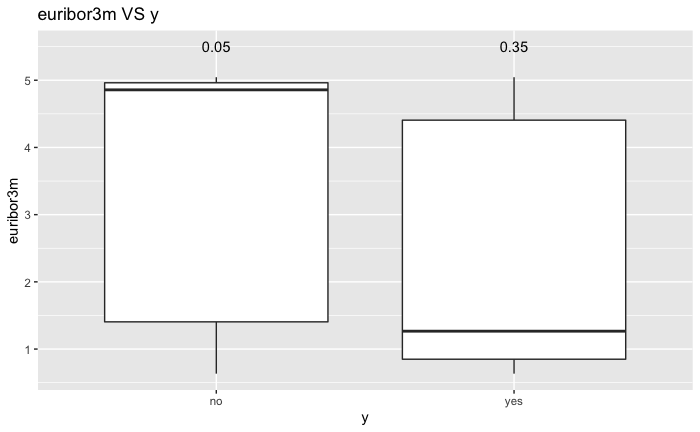

```r
ggplot(D, aes(x=y, y=euribor3m)) + geom_boxplot() + ggtitle("euribor3m VS y") +
  annotate("text", x = 1:2, y=5.5, label = round(euribor3mRatio,2))
```

#### 2.4.5. `nr.employed`

The feature `nr.employed` is number of employees - quarterly indicator (numeric). It has a strong relationship with `y`.

```r
summary(D$nr.employed)
```

```
   Min. 1st Qu.  Median    Mean 3rd Qu.    Max.
   4964    5099    5191    5167    5228    5228
```

```r
summary(D$nr.employed[D$y=="yes"])
```

```
   Min. 1st Qu.  Median    Mean 3rd Qu.    Max.
   4964    5018    5099    5095    5191    5228
```

```r
summary(D$nr.employed[D$y=="no"])
```

```
   Min. 1st Qu.  Median    Mean 3rd Qu.    Max.
   4964    5099    5196    5176    5228    5228
```

```r
m0 = median(D$nr.employed[D$y=="no"])
m1 = median(D$nr.employed[D$y=="yes"])

employedRatio = c(sum(D$y=="yes" & D$nr.employed>=m0)/sum(D$nr.employed>=m0), sum(D$y=="yes" & D$nr.employed<=m1)/sum(D$nr.employed<=m1))
employedRatio
```

```
[1] 0.05512878 0.24455475
```

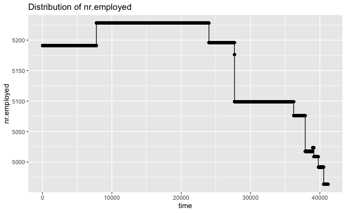

```r
ggplot(D, aes(x=1:nrow(D), y=nr.employed)) + geom_point() + geom_line() +
  xlab("time") + ggtitle("Distribution of nr.employed")
```

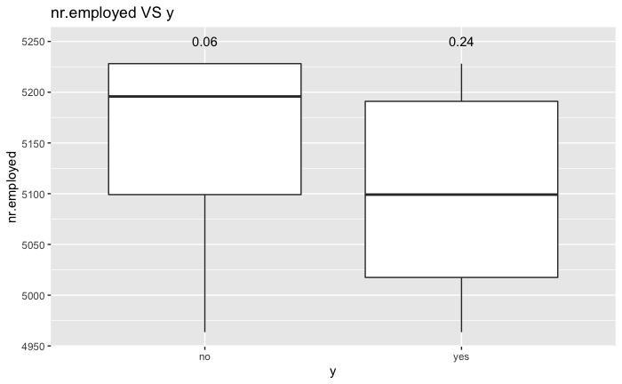

```r
ggplot(D, aes(x=y, y=nr.employed)) + geom_boxplot() + ggtitle("nr.employed VS y") +
  annotate("text", x = 1:2, y=5250, label = round(employedRatio,2))

ggsave(filename = "~/Downloads/bank-additional/fig6.png")
```

## 3. Insights

Clients who are student or illiterate are likely to subscribe ($27\%$ chance to subscribe), while those who are blue-collar or with elementary/middle school diploma are unlikely to do so ($8\%$ chance to subscribe).

Clients who had a contact in March, Dec, Sep or Oct are likely to subscribe ($47\%$ chance to subscribe), while those who had contacted in May are unlikely to do so ($6\%$ chance to subscribe).

Clients who had a 7 mins or more duration contact are to subscribe ($40\%$ chance to subscribe), while clients are to subscribe ($2\%$ chance to subscribe) if the contact duration is less than 2 mins.

Clients who had bought the product from the previous marketing campaign are likely to subscribe again ($65\%$ chance to subscribe), while those who are new or didn’t subscribe previously are unlikely to do so ($9\%$ chance to subscribe).

Clients are likely to subscribe when economic is not good, i.e., the number of employees is lower than 5100 ($24\%$ chance to subscribe), while clients are unlikely to subscribe when the number of employees is higher than 5200 ($6\%$ chance to subscribe).